# Assignment 3

USER

January 29, 2018

# x-y plot with leverage

The scatterplot shows the relationship between x and y and size representing leverage of each point. It is clear that leverage increases for large x. There are only a few points with high leveage, but the magnitude of the leverage is very large.

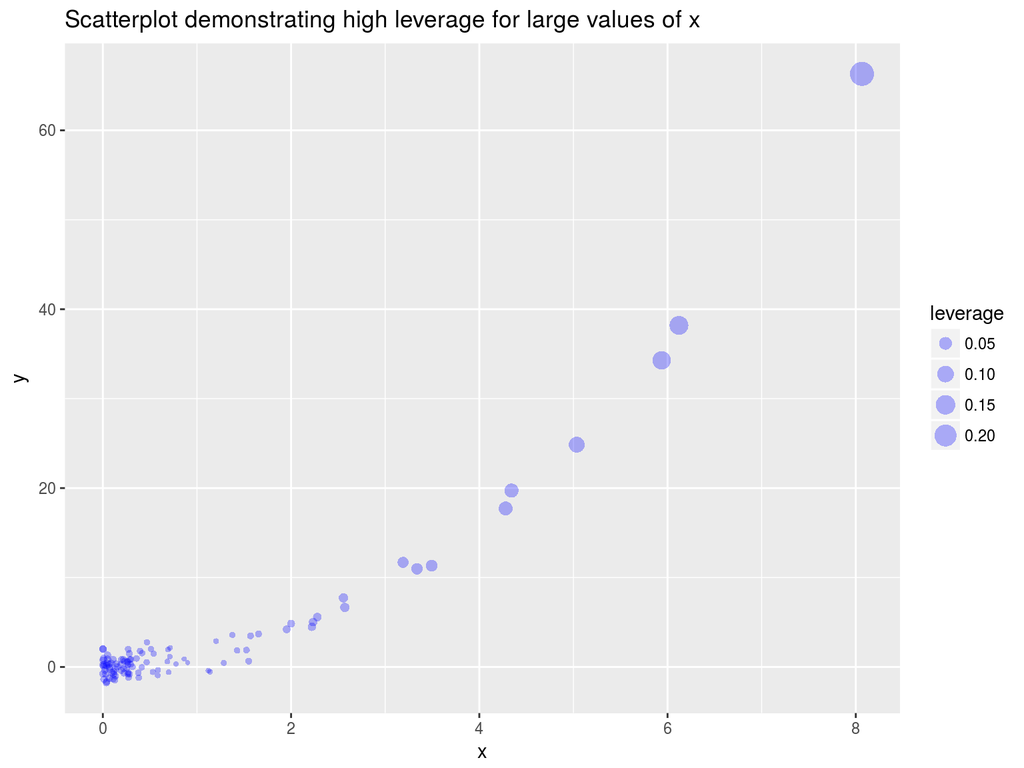

# Means and Sds of Beta Hats

We simulate the model with 25,000 repetitions.

```
##          Mean    SD
## homo   -0.004 0.608
## hetero  0.000 0.588
```

In both the homoskedastic and heteroskedastic cases, the estimate of beta is unbiased.

# SEs of Beta Hats

```
## $Homo
##         Mean    SD reject.rate
## Const  0.603 0.081       0.049
## HC1    0.486 0.202       0.166
## Oracle 0.609 0.000       0.041
##
## $Hetero
##         Mean    SD reject.rate
## Const  0.332 0.051       0.255
## HC1    0.450 0.218       0.203
## Oracle 0.593 0.000       0.038
```

Homoskedastic case (top panel): 1. Conventional: unbiased, correct rejection rate 2. HC1: downward biased, over-rejecting () 3. Oracle (theoretical): unbiased, under-rejecting (t vs. N(0,1))

Conventiontal SE well approximates t distribution (next slide)

Both are biased; t-distribution well approximated? Theoretically may not.

# Plots of t-value distribution

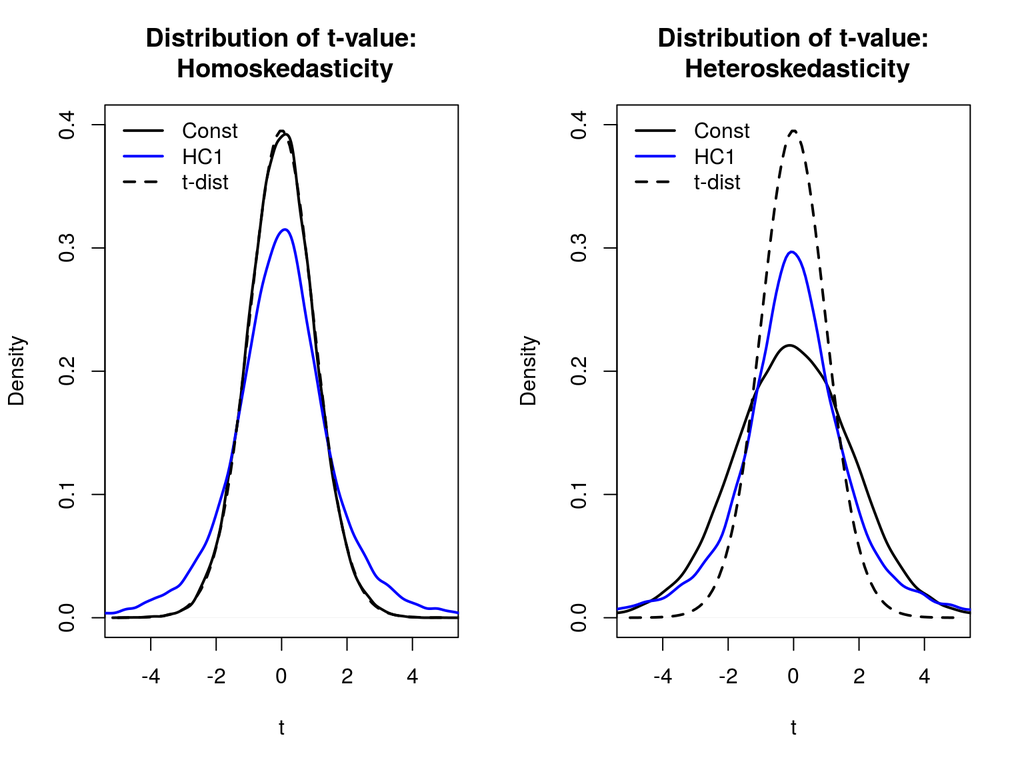

# Summary

- Unbiasedness of beta hat is not affected by the variances of the DGPs
- Heteroskedasticity introduces bias in the SEs and wrong sizes
- Heteroskedasticity-consistent variance estimators such as HC1 reduce bias of SEs with heteroskedastic data, but introduce bias in homoskedastic data
- Under heteroskedasticity, unclear whether distribution of conventional t-test statistic is approximately a t distribution